# Test a Perceptual Phenomenon

### Analyzing the Stroop Effect

Perform the analysis in the space below. Remember to follow [the instructions](https://docs.google.com/document/d/1-OkpZLjG_kX9J6LIQ5IltsqMzVWjh36QpnP2RYpVdPU/pub?embedded=True) and review the [project rubric](https://review.udacity.com/#!/rubrics/71/view) before submitting. Once you've completed the analysis and write up, download this file as a PDF or HTML file and submit in the next section.

(1) What is the independent variable? What is the dependent variable?

- *Independent variable*: conditions (congruent words condition or incongruent words condition)
- *Dependent variable*: the time to recognize the colors correctly in equally-sized lists

(2) What is an appropriate set of hypotheses for this task? What kind of statistical test do you expect to perform? Justify your choices.

- Let ${\mu_{con}}$ be the population mean response time to recognize the colors in congruent condition, and ${\mu_{in}}$ be the population mean response time in incongruent conditions. Then we have the null and alternative hypothesis as follows:  
  ${H_0}:{\mu _{in}} = {\mu _{con}}$  
  ${H_a}:{\mu _{in}} \ne {\mu _{con}}$  
  The null hypothesis states that the population mean response time to name the colors in congruent condition is equal to the population mean response time in incongruent condition. The alternative hypothesis states that the population mean response time to recognize the colors in congruent condition is not the same as the population mean response time in incongruent condition.
- Because we have less than 30 samples for each group and the population variance is unkown, we should use t-test. Besides, we compare the population means of two related groups to decide whether there is a statistically significant difference between them, and each participant is tested in both the congruent and incongruent conditions. Hence, we use dependent t-test (paired t-test).
- We also find that the difference between the congruent and incongruent conditions is (statistically) significant, and we reject the null hypothesis and accept the alternative hypothesis.

(3) Report some descriptive statistics regarding this dataset. Include at least one measure of central tendency and at least one measure of variability. The name of the data file is 'stroopdata.csv'.

```python
from scipy import stats
import matplotlib.pyplot as plt
%matplotlib inline
import pandas as pd
plt.style.use('ggplot')

dataFrame = pd.read_csv('stroopdata.csv')
congruentData, incongruentData = dataFrame['Congruent'],  dataFrame['Incongruent']
differenceData = congruentData - incongruentData
df2 = pd.DataFrame({"Difference":differenceData})
pd.concat([dataFrame, df2]).describe()
```

|  | Congruent | Difference | Incongruent |
| --- | --- | --- | --- |
| count | 24.000000 | 24.000000 | 24.000000 |
| mean | 14.051125 | -7.964792 | 22.015917 |
| std | 3.559358 | 4.864827 | 4.797057 |
| min | 8.630000 | -21.919000 | 15.687000 |
| 25% | 11.895250 | -10.258500 | 18.716750 |
| 50% | 14.356500 | -7.666500 | 21.017500 |
| 75% | 16.200750 | -3.645500 | 24.051500 |
| max | 22.328000 | -1.950000 | 35.255000 |

- In the above table, we show the central tendency (mean value) from congruent, difference data and incongruent data. We find that the mean response time in incongruent condition is longer than congruent condition.
- For varaibility we show the standardard deviation, where incongruent data is more spread out than congruent data.
- Besides, we also show the number of samples, min, max as well as 25%, 50% and 75% percentiles.

(4) Provide one or two visualizations that show the distribution of the sample data. Write one or two sentences noting what you observe about the plot or plots.

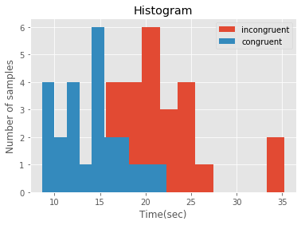

```python
plt.hist(incongruentData, label=['incongruent'])
plt.hist(congruentData, label=['congruent'])
plt.xlabel('Time(sec)')
plt.ylabel('Number of samples')
plt.title('Histogram')
plt.legend()
plt.show()
```

- For congruent data, the response time range is rougly from 8 to 23. For incongruent data, the range is from 16 to 35. Noticebly the mean of the time to recognize the incongruent word is to the right of the congruent data. There seems to be two outliers in the incongruent data with time values around 34secs.

(5) Now, perform the statistical test and report the results. What is the confidence level and your critical statistic value? Do you reject the null hypothesis or fail to reject it? Come to a conclusion in terms of the experiment task. Did the results match up with your expectations?

```python
ttestRes = stats.ttest_rel(incongruentData, congruentData)
print(ttestRes)
```

```
Ttest_relResult(statistic=8.020706944109957, pvalue=4.1030005857111781e-08)
```

- We use two tailed t-test with 95% confidence level. According to the t table, the critical value is 2.069 (degree of freedom is 23) on the positive side.
- The tscore is 8.02, which is higher than the critical value in the positive side. Thus, we should reject the null hypothesis. (Or the pvalue 4.1e-8 is much less than 0.05, so we reject $H_0$).
- The experimental results match up with our expectations, because there's a significant difference between the congruent and incongruent data with over 95% confidence. Besides, intuitively, the incongruent condition takes much longer time to recognize the color.

(6) Optional: What do you think is responsible for the effects observed? Can you think of an alternative or similar task that would result in a similar effect? Some research about the problem will be helpful for thinking about these two questions!

- The brain will automatically associate the text/shape of a word with its color. If those two do not match, prefrontal cortex (PFC) will take additional time to encode the meaning of the word text. For more details, one can refer to https://www.sciencedaily.com/releases/2013/12/131219102759.htm
- Similar task to the stroop effect includes the case where integers with different values have different font sizes, and we want to recognize the values of the digits. Say 235 is smaller in value but large in font(60pts), and digit 245 is large in value but small in font(20pts).